# Third Week: Exploratory Data Analysis

Barcelona plays a more beautiful game but real madrid plays with a better strategy.  
Barcelona has better offenders but real madrid has better defenders.  
Barca’s defense lines has become better and reals defense line has become worse these days; also barce’s offense has an small advantage over real’s.  
Barca is seriously gaining on real! :)  
Barca’s games are more pleasing to watch in comparison to real’s games!

```r
team_results %>% group_by(Season, team) %>% mutate(GS = sum(GS), GR = sum(GR)) -> gs_and_gr

gs_and_gr %>% filter(team == 'FC Barcelona' | team == 'Real Madrid') %>% group_by(team) %>%
  hchart(type = 'line', hcaes(x = Season, y = GS, group = team))
```

[interactive chart not shown]

```r
gs_and_gr %>% filter(team == 'FC Barcelona' | team == 'Real Madrid') %>% group_by(team) %>%
  hchart(type = 'line', hcaes(x = Season, y = GR, group = team))
```

[interactive chart not shown]

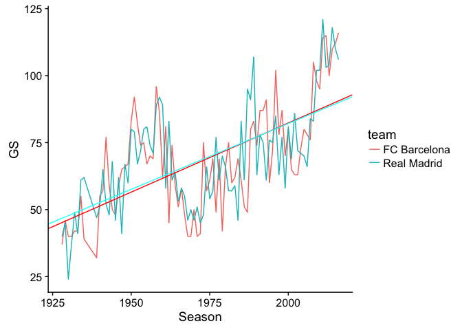

```r
c_gs_barca <- coef(lm(GS~Season, data = gs_and_gr %>% filter(team == 'FC Barcelona')))
c_gs_realm <- coef(lm(GS~Season, data = gs_and_gr %>% filter(team == 'Real Madrid')))
gs_and_gr %>% filter(team == 'FC Barcelona' | team == 'Real Madrid') %>% group_by(team) %>%
  ggplot(aes(x = Season, y = GS, group = team, colour = team)) + geom_line() +
  geom_abline(intercept = c_gs_barca[1], slope = c_gs_barca[2], color = 'red') +
  geom_abline(intercept = c_gs_realm[1], slope = c_gs_realm[2], color = 'cyan')
```

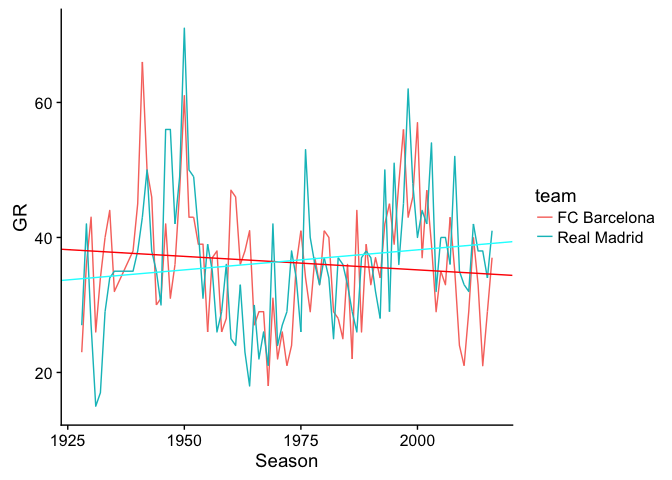

```r
c_gr_barca <- coef(lm(GR~Season, data = gs_and_gr %>% filter(team == 'FC Barcelona')))
c_gr_realm <- coef(lm(GR~Season, data = gs_and_gr %>% filter(team == 'Real Madrid')))
gs_and_gr %>% filter(team == 'FC Barcelona' | team == 'Real Madrid') %>% group_by(team) %>%
  ggplot(aes(x = Season, y = GR, group = team, colour = team)) + geom_line() +
  geom_abline(intercept = c_gr_barca[1], slope = c_gr_barca[2], color = 'red') +
  geom_abline(intercept = c_gr_realm[1], slope = c_gr_realm[2], color = 'cyan')
```

```r
team_points %>% group_by(Season) %>% arrange(desc(PTS)) %>% slice(2) %>% arrange(Season) %>%
  mutate(GB = GS - GR) -> season_second_champions

full_join(
  season_champions %>% select(Season, team_1 = team, PTS_1 = PTS, GB_1 = GB),
  season_second_champions %>% select(Season, team_2 = team, PTS_2 = PTS, GB_2 = GB),
  by = 'Season'
) %>% mutate(pts_gap = PTS_1 - PTS_2, gb_gap = GB_1 - GB_2) %>% arrange(desc(pts_gap)) %>% ungroup() %>%
  slice(1:10) -> champion_pts_gap

champion_pts_gap %>% print()
```

```
## # A tibble: 10 x 9
##    Season team_1       PTS_1  GB_1 team_2       PTS_2  GB_2 pts_gap gb_gap
##     <dbl> <chr>        <dbl> <int> <chr>        <dbl> <int>   <dbl>  <int>
##  1   1962 Real Madrid   72.0    50 Atletico Ma…  51.0    25    21.0     25
##  2   1960 Real Madrid   76.0    64 Atletico Ma…  57.0    22    19.0     42
##  3   1985 Real Madrid   82.0    50 FC Barcelona  63.0    25    19.0     25
##  4   1974 Real Madrid   70.0    32 Real Zarago…  53.0    11    17.0     21
##  5   1987 Real Madrid   90.0    69 Real Socied…  73.0    28    17.0     41
##  6   1990 FC Barcelona  82.0    41 Real Madrid   66.0    26    16.0     15
##  7   1984 FC Barcelona  74.0    44 Atletico Ma…  59.0    23    15.0     21
##  8   2012 FC Barcelona 100      75 Real Madrid   85.0    61    15.0     14
##  9   1989 Real Madrid   88.0    69 FC Barcelona  74.0    44    14.0     25
## 10   1968 Real Madrid   65.0    25 UD Las Palm…  53.0    11    12.0     14
```

```r
champion_pts_gap %>% hchart(type = 'column', hcaes(x = team_1, y = pts_gap))
```

[interactive chart not shown]

Other than FC Barcelona and Real Madrid, Athletic Bilbao is the only team which has never fell from La Liga to Liga Adelante.

```r
fdb %>% select(home, Season) %>% unique() %>% group_by(home) %>%  summarise(participations = n()) %>%
  arrange(desc(participations)) %>% hchart(type = 'column', hcaes(x = home, y = participations))
```

[interactive chart not shown]

Only 8 teams have ever won the La Liga! (based on resluts from Q1).

```r
team_champs %>% hchart(type = 'column', hcaes(x = team, y = championships))
```

[interactive chart not shown]